# Part I: Exploration

## Eslam Elassal

Over 180 000 individual rides in a bike-sharing system spanning the greater San Francisco Bay area in 2019 are included in this data collection. Details contained:

- Duration of journey
- Start and end time, and location of journey
- Bike ID
- User ID, DoB, and gender

## Preliminary Wrangling

```python
import numpy as np
import pandas as pd
import matplotlib.pyplot as plt
import seaborn as sns
%matplotlib inline
```

```python
# Load data set a display preview sample
df_raw = pd.read_csv('201902-fordgobike-tripdata.csv')
df_raw.sample(8)
```

|  | duration_sec | start_time | end_time | start_station_id | start_station_name | start_station_latitude | start_station_longitude | end_station_id | end_station_name | end_station_latitude | end_station_longitude | bike_id | user_type | member_birth_year | member_gender | bike_share_for_all_trip |
| --- | --- | --- | --- | --- | --- | --- | --- | --- | --- | --- | --- | --- | --- | --- | --- | --- |
| 105744 | 568 | 2019-02-13 21:06:49.0160 | 2019-02-13 21:16:17.4780 | 3.0 | Powell St BART Station (Market St at 4th St) | 37.786375 | -122.404904 | 14.0 | Clay St at Battery St | 37.795001 | -122.399970 | 319 | Customer | 1983.0 | Male | No |
| 107608 | 491 | 2019-02-13 15:36:53.4830 | 2019-02-13 15:45:04.5530 | 60.0 | 8th St at Ringold St | 37.774520 | -122.409449 | 67.0 | San Francisco Caltrain Station 2 (Townsend St... | 37.776639 | -122.395526 | 438 | Subscriber | 1960.0 | Female | No |
| 91380 | 232 | 2019-02-16 08:54:53.2610 | 2019-02-16 08:58:45.9160 | 341.0 | Fountain Alley at S 2nd St | 37.336188 | -121.889277 | 280.0 | San Fernando St at 7th St | 37.337122 | -121.883215 | 4008 | Subscriber | 1995.0 | Male | Yes |
| 55756 | 955 | 2019-02-21 09:31:46.4420 | 2019-02-21 09:47:41.9570 | 118.0 | Eureka Valley Recreation Center | 37.759177 | -122.436943 | 5.0 | Powell St BART Station (Market St at 5th St) | 37.783899 | -122.408445 | 5966 | Subscriber | NaN | NaN | No |
| 111258 | 915 | 2019-02-12 17:07:35.2260 | 2019-02-12 17:22:50.6030 | 88.0 | 11th St at Bryant St | 37.770030 | -122.411726 | 19.0 | Post St at Kearny St | 37.788975 | -122.403452 | 5148 | Subscriber | 1956.0 | Female | Yes |
| 105988 | 317 | 2019-02-13 19:29:17.4680 | 2019-02-13 19:34:34.5810 | 116.0 | Mississippi St at 17th St | 37.764802 | -122.394771 | 336.0 | Potrero Ave and Mariposa St | 37.763281 | -122.407377 | 5232 | Customer | 1986.0 | Male | No |
| 31418 | 558 | 2019-02-24 16:49:41.4750 | 2019-02-24 16:58:59.7720 | 324.0 | Union Square (Powell St at Post St) | 37.788300 | -122.408531 | 66.0 | 3rd St at Townsend St | 37.778742 | -122.392741 | 5353 | Subscriber | 1995.0 | Male | No |
| 120006 | 892 | 2019-02-11 17:16:39.1000 | 2019-02-11 17:31:31.3930 | 115.0 | Jackson Playground | 37.765026 | -122.398773 | 118.0 | Eureka Valley Recreation Center | 37.759177 | -122.436943 | 5011 | Subscriber | 1974.0 | Male | No |

```python
# print the shape
print(df_raw.shape)
```

```
(183412, 16)
```

```python
# Display data types, non-null counts
df_raw.info()
```

```
<class 'pandas.core.frame.DataFrame'>
RangeIndex: 183412 entries, 0 to 183411
Data columns (total 16 columns):
 #   Column                   Non-Null Count   Dtype
---  ------                   --------------   -----
 0   duration_sec             183412 non-null  int64
 1   start_time               183412 non-null  object
 2   end_time                 183412 non-null  object
 3   start_station_id         183215 non-null  float64
 4   start_station_name       183215 non-null  object
 5   start_station_latitude   183412 non-null  float64
 6   start_station_longitude  183412 non-null  float64
 7   end_station_id           183215 non-null  float64
 8   end_station_name         183215 non-null  object
 9   end_station_latitude     183412 non-null  float64
 10  end_station_longitude    183412 non-null  float64
 11  bike_id                  183412 non-null  int64
 12  user_type                183412 non-null  object
 13  member_birth_year        175147 non-null  float64
 14  member_gender            175147 non-null  object
 15  bike_share_for_all_trip  183412 non-null  object
dtypes: float64(7), int64(2), object(7)
memory usage: 22.4+ MB
```

```python
# unique values
df_raw.nunique()
```

```
duration_sec                 4752
start_time                 183401
end_time                   183397
start_station_id              329
start_station_name            329
start_station_latitude        334
start_station_longitude       335
end_station_id                329
end_station_name              329
end_station_latitude          335
end_station_longitude         335
bike_id                      4646
user_type                       2
member_birth_year              75
member_gender                   3
bike_share_for_all_trip         2
dtype: int64
```

### Preliminary findings

```python
# copy of the dataset
df = df_raw.copy()
```

```python
# Drop unused columns
df.drop(['start_station_id', 'end_station_id', 'bike_id', 'bike_share_for_all_trip'],
        axis = 1, inplace = True)
# Check columns
df.head(0)
```

|  | duration_sec | start_time | end_time | start_station_name | start_station_latitude | start_station_longitude | end_station_name | end_station_latitude | end_station_longitude | user_type | member_birth_year | member_gender |
| --- | --- | --- | --- | --- | --- | --- | --- | --- | --- | --- | --- | --- |

```python
# Drop null values
df.dropna(inplace = True)
# Non-Null Counts
df.info()
```

```
<class 'pandas.core.frame.DataFrame'>
Int64Index: 174952 entries, 0 to 183411
Data columns (total 12 columns):
 #   Column                   Non-Null Count   Dtype
---  ------                   --------------   -----
 0   duration_sec             174952 non-null  int64
 1   start_time               174952 non-null  object
 2   end_time                 174952 non-null  object
 3   start_station_name       174952 non-null  object
 4   start_station_latitude   174952 non-null  float64
 5   start_station_longitude  174952 non-null  float64
 6   end_station_name         174952 non-null  object
 7   end_station_latitude     174952 non-null  float64
 8   end_station_longitude    174952 non-null  float64
 9   user_type                174952 non-null  object
 10  member_birth_year        174952 non-null  float64
 11  member_gender            174952 non-null  object
dtypes: float64(5), int64(1), object(6)
memory usage: 17.4+ MB
```

```python
# Change data types
df.start_time = pd.to_datetime(df.start_time)
df.end_time = pd.to_datetime(df.end_time)
df.user_type = df.user_type.astype('category')
df.member_gender = df.member_gender.astype('category')
df.member_birth_year = df.member_birth_year.astype('int64')
# Check data types
df.info()
```

```
<class 'pandas.core.frame.DataFrame'>
Int64Index: 174952 entries, 0 to 183411
Data columns (total 12 columns):
 #   Column                   Non-Null Count   Dtype
---  ------                   --------------   -----
 0   duration_sec             174952 non-null  int64
 1   start_time               174952 non-null  datetime64[ns]
 2   end_time                 174952 non-null  datetime64[ns]
 3   start_station_name       174952 non-null  object
 4   start_station_latitude   174952 non-null  float64
 5   start_station_longitude  174952 non-null  float64
 6   end_station_name         174952 non-null  object
 7   end_station_latitude     174952 non-null  float64
 8   end_station_longitude    174952 non-null  float64
 9   user_type                174952 non-null  category
 10  member_birth_year        174952 non-null  int64
 11  member_gender            174952 non-null  category
dtypes: category(2), datetime64[ns](2), float64(4), int64(2), object(2)
memory usage: 15.0+ MB
```

```python
# Add journey duration minutes column
df['duration_min'] = df.duration_sec/60
#I will now exclude numbers for trips lasting more than an hour
#because they probably don't involve consistent travel and will result in anomalies when calculating speeds.
indeces = df[df['duration_min'] > 60].index
df.drop(indeces, inplace = True)
#Only a minor percentage of the data has been deleted when compared to the count above.
df.duration_min.describe()
```

```
count    173566.000000
mean         10.308359
std           7.396235
min           1.016667
25%           5.350000
50%           8.450000
75%          13.000000
max          59.933333
Name: duration_min, dtype: float64
```

```python
# Add age column and drop DoB
df['age'] = 2019 - df.member_birth_year
df.drop(['member_birth_year'], axis = 1, inplace = True)
# Remove any entires with an age value over 100
indeces = df[df['age'] > 80].index
df.drop(indeces, inplace = True)
# age distribution
df.age.describe()
```

```
count    173374.000000
mean         34.119389
std           9.873882
min          18.000000
25%          27.000000
50%          32.000000
75%          39.000000
max          80.000000
Name: age, dtype: float64
```

```python
#The function to convert degrees to radians should be included,
#along with a column showing the distance traveled based on the coordinates.
def degrees_to_radians(degrees):
    return degrees * np.pi / 180
# calculating distance between two points
def distance(lat1, lon1, lat2, lon2):
    earth_radius_Km = 6371
    d_lat = degrees_to_radians(lat2-lat1)
    d_lon = degrees_to_radians(lon2-lon1)
    lat1 = degrees_to_radians(lat1)
    lat2 = degrees_to_radians(lat2)
    a = np.sin(d_lat/2) * np.sin(d_lat/2) + np.sin(d_lon/2) * np.sin(d_lon/2) * np.cos(lat1) * np.cos(lat2)
    c = 2 * np.arctan2(np.sqrt(a), np.sqrt(1-a))
    return 6371 * c
#insert distance column
df['distance'] = distance(df.start_station_latitude, df.start_station_longitude,
                          df.end_station_latitude, df.end_station_longitude)
#Deleting entries where the distance is zero, since that means the bike went back to the starting point.
#Errors would arise if speed were calculated based on these findings.
indeces = df[df['distance'] == 0.000000].index
df.drop(indeces, inplace = True)
# remove coordinate columns
df.drop(['start_station_latitude', 'start_station_longitude', 'end_station_latitude', 'end_station_longitude'],
       axis = 1, inplace = True)
# print the data
df.head(1)
```

|  | duration_sec | start_time | end_time | start_station_name | end_station_name | user_type | member_gender | duration_min | age | distance |
| --- | --- | --- | --- | --- | --- | --- | --- | --- | --- | --- |
| 4 | 1585 | 2019-02-28 23:54:18.549 | 2019-03-01 00:20:44.074 | Frank H Ogawa Plaza | 10th Ave at E 15th St | Subscriber | Male | 26.416667 | 45 | 2.409301 |

```python
# Add column speed
df['speed'] = df.distance / (df.duration_min / 60)
# print data
df.head(1)
```

|  | duration_sec | start_time | end_time | start_station_name | end_station_name | user_type | member_gender | duration_min | age | distance | speed |
| --- | --- | --- | --- | --- | --- | --- | --- | --- | --- | --- | --- |
| 4 | 1585 | 2019-02-28 23:54:18.549 | 2019-03-01 00:20:44.074 | Frank H Ogawa Plaza | 10th Ave at E 15th St | Subscriber | Male | 26.416667 | 45 | 2.409301 | 5.47223 |

## Univariate Exploration

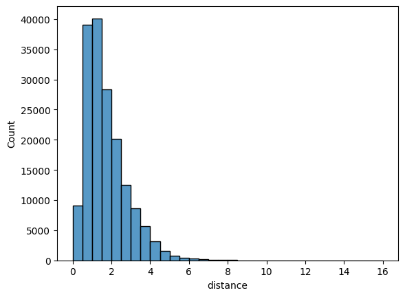

```python
# histogram of distance
bins = np.arange(0, df['distance'].max()+0.5, 0.5)
sns.histplot(data=df, x='distance', bins=bins);
```

This demonstrates that the mode is approximately 1 km, and the great majority of trips are less than 3 km.

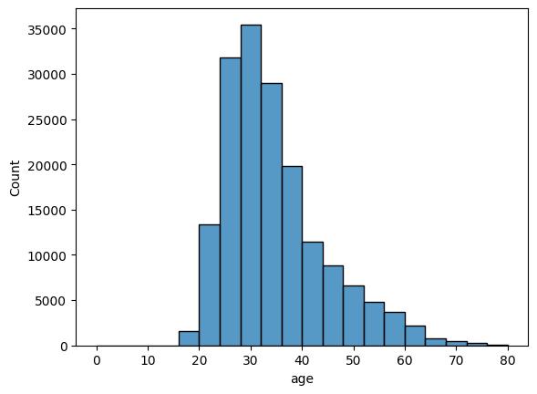

```python
#histogram of age
bins = np.arange(0, df['age'].max()+4, 4)
sns.histplot(data=df, x='age', bins=bins);
```

This indicates that the majority of users are in the 20–40 age range, with a peak around 30 years old, after which there is an exponential fall.

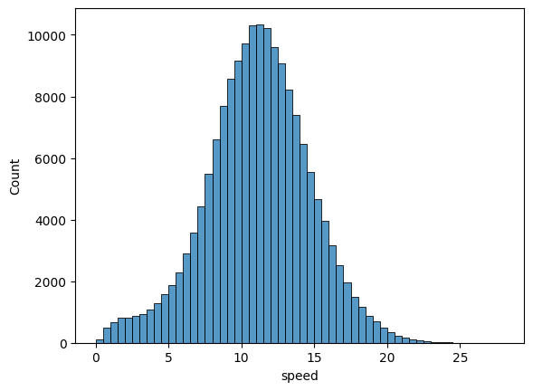

```python
# histogram of speed
bins = np.arange(0, df['speed'].max()+0.5, 0.5)
sns.histplot(data=df, x='speed', bins=bins);
```

This shows an almost symetrical bell curve with 11-12kph being the most common speed.

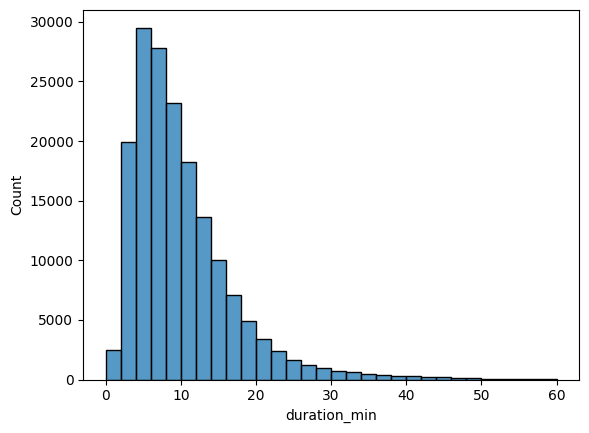

```python
# histogram duration
bins = np.arange(0, df['duration_min'].max()+2, 2)
sns.histplot(data=df, x='duration_min', bins=bins);
```

The distribution of duration and distance is similar, with the majority of trips taking less than 15 minutes.

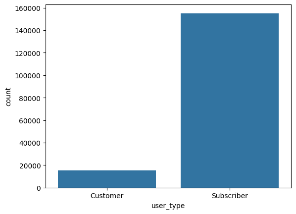

```python
# count plot of user_type
sns.countplot(data=df, x='user_type', color='tab:blue');
```

Subscribing is significantly more prevalent than purchasing. This suggests that most customers are locals who frequently use the service instead of visitors who are only visiting San Francisco.

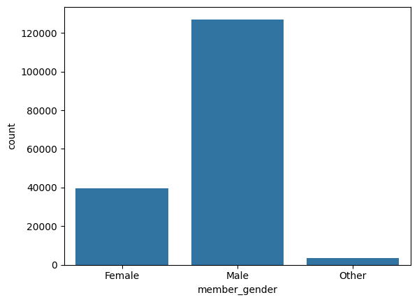

```python
# count plot of gender
sns.countplot(data=df, x='member_gender', color='tab:blue');
```

Roughly three times as many men as women utilize the service. Neilsberg Research reports that while there are 21,373 fewer women than men in San Francisco, this difference is less than 3% due to the city's large population.

## Bivariate Exploration

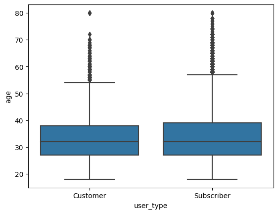

```python
# box plot of age, user types
sns.boxplot(data=df, x='user_type', y='age', color='tab:blue');
```

The age distribution of each sort of user seems to differ from one another quite little. Because there are so many more data points for that particular user type, there may be a minor rise in IQR and the number of outliers for the subscribers.

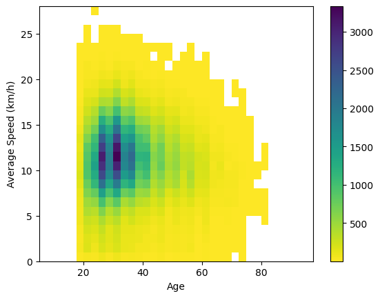

```python
# heat map of age vs speed
bins_x = np.arange(5, 97+2.5, 2.5)
bins_y = np.arange(0, 28+1, 1)
plt.hist2d(data=df, x='age', y='speed', cmin=0.5, cmap='viridis_r', bins=[bins_x, bins_y]);
plt.colorbar();
plt.xlabel('Age')
plt.ylabel('Average Speed (km/h)');
```

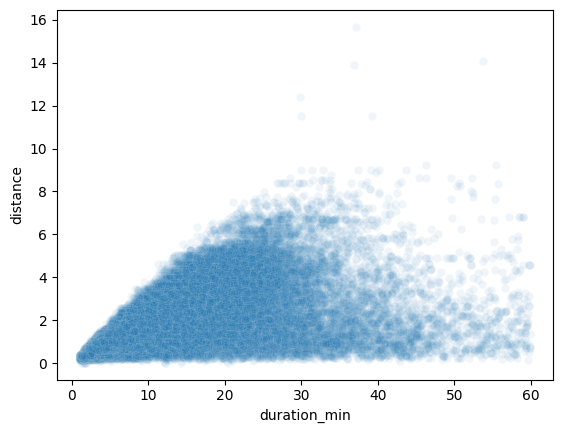

```python
# scatter plot of duration vs distance
sns.scatterplot(data=df, x='duration_min', y='distance', alpha = 1/15);
```

In order to facilitate understanding of this visualization, I have increased the transparency of the data points. We can clearly observe from this scatter figure that most users' speeds are limited by the specification of the diaganol border, with very few outliers falling above it.

## Multivariate Exploration

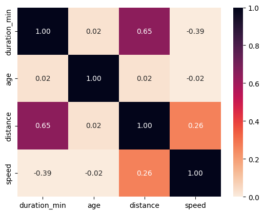

```python
#correlation heat map matrix for the numeric data being observed
cols = ['duration_min', 'age', 'distance', 'speed']
sns.heatmap(df[cols].corr(), cmap='rocket_r', annot=True,
          fmt='.2f', vmin=0);
```

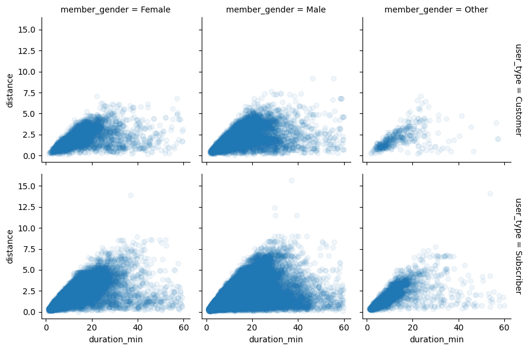

```python
#facet grid to show duration vs distance, split by gender and user type
g = sns.FacetGrid(data=df, col = 'member_gender', row = 'user_type', margin_titles=True);
g.map(plt.scatter, 'duration_min','distance', alpha = 1/15);
```

The only discernable difference between genders is that there are far more data points for men. There is however a slight difference between the user types in the shape created by the plot.

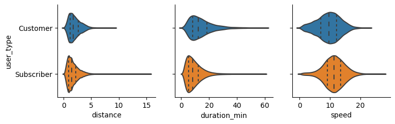

```python
# pair grid to compare user type in terms of distance, duration, and speed
g = sns.PairGrid(data=df, x_vars=['distance', 'duration_min', 'speed'],
                y_vars=['user_type'])
g.map(sns.violinplot, inner='quartile');
```

```python
df.to_csv('go_bike_clean.csv')
```

This demonstrates that while subscribers travel somewhat less ground on average, they are consistently quicker and ride their bikes for shorter periods of time.

## Final conclusion

Learning or data translation was quite simple, such as translating DoG to age; nevertheless, I had to first compute the speed and distance of a voyage using the coordinate values in order to respond to any queries about it.

### Summary Findings

The gradient of the resulting cone of data points on scatter plots suggests that the subscriber's average speed is higher than the user's. This association is more evident in the violin plots.

```python
%%shell
jupyter nbconvert --to html /content/Part_1_notebook.ipynb
```

```
[NbConvertApp] Converting notebook /content/Part_1_notebook.ipynb to html
[NbConvertApp] Writing 1311913 bytes to /content/Part_1_notebook.html
```